# Data Science Capstone: Milestone Report

A. Kramer

March 12, 2016

# Executive Summary

This is a milestone report prepared for the final project of the Data Science Capstone course offered by Coursera. The goal of this project is to build a word-prediction model and a Shiny application to employ the model developed. The application will take either one, two, or three words and display prediction of the next word. This Milestone Report covers exploratory data analysis conducted on a small subset of the data supplied for the project. This report also details creation and combinations of multiple corpora, generation of TermDocumentMatrix objects and finally, creation of data frames for unigrams, bigrams, trigrams, and quadgrams.

# Obtaining and Loading Data

The code below details downloading text data, uncompressing the data, and loading english dictionary data into R objects for the purposes of the exploratory data analysis. The code is self-documented providing detailed explanation of the activities performed in the code.

```r
# Set working directory
setwd("C:\\Users\\Aleksey\\Documents\\School\\coursera\\Data Science Capstone\\week2")

## Set seed
set.seed(63545)

## Suppress warnings
options(warn=-1)

############################### GET DATA ####################################################

## Get the data
datafile <- 'https://d396qusza40orc.cloudfront.net/dsscapstone/dataset/Coursera-SwiftKey.zip'

## Download file if not exists
if(!file.exists('Coursera-SwiftKey.zip')) {
    download.file(datafile, 'Coursera-SwiftKey.zip')
}

## Unzip downloaded file if not already unzipped
if(!file.exists('final')) {
    unzip('./Coursera-SwiftKey.zip')
}

############################### LOAD DATA ##################################################

## Read blogs file
conn <- file('./final/en_US/en_US.blogs.txt', 'r')
blogs <- readLines(conn, encoding="UTF-8", skipNul=TRUE)
close(conn)

## convert to ascii
blogs <- iconv(blogs, "UTF-8", "ASCII", sub="")

## Read news file
conn <- file('./final/en_US/en_US.news.txt', 'rb')
news <- readLines(conn, encoding="UTF-8", skipNul=TRUE)
close(conn)

## convert to ascii
news <- iconv(news, "UTF-8", "ASCII", sub="")

## Read twitter file
conn <- file('./final/en_US/en_US.twitter.txt', 'r')
twitter <- readLines(conn, encoding="latin1", skipNul=TRUE)
close(conn)

## Convert to ascii
twitter <- iconv(twitter, from = "latin1", to = "ASCII", sub="")

## Cleanup data file names and connections
rm(conn, datafile)
```

# File Level Statistics

The code below shows the basic stats about the files and objects loaded. I employed simple **wc** command to display the number of lines, words, and characters in each file. I confirmed the line counts by displaying line count of loaded data sets and the count of line in the data files. The code is self-documented providing detailed explanation of the activities performed in the code.

```r
############################### BASIC STATS ###############################################
## Suppress warnings
options(warn=-1)

## Count number of lines, words, and characters in files and display results to the users
system("wc ./final/en_US/en_US.blogs.txt",intern=TRUE)
```

```
## [1] " 899288 37334131 210160014 ./final/en_US/en_US.blogs.txt"
```

```r
system("wc ./final/en_US/en_US.news.txt",intern=TRUE)
```

```
## [1] "1010242 34372530 205811889 ./final/en_US/en_US.news.txt"
```

```r
system("wc ./final/en_US/en_US.twitter.txt",intern=TRUE)
```

```
## [1] "2360148 30373583 167105338 ./final/en_US/en_US.twitter.txt"
```

```r
## Display number of lines in loaded files
length(blogs)
```

```
## [1] 899288
```

```r
length(news)
```

```
## [1] 1010242
```

```r
length(twitter)
```

```
## [1] 2360148
```

# Create Sample Data Sets (Observations)

The next step is to create a manageable data set to work on my old i5 core, 64bit computer. My computer cannot process large amounts of data efficiently. Thus a sample size of 1% was selected. The code is self-documented providing detailed explanation of the activities performed in the code. Additionally, I have tried processing 15% of data on i7 core computer and failed to complete processing in a reasonable amount of time. The data sets are very large.

```r
############################### SAMPLING DATA ##############################################
## Suppress warnings
options(warn=-1)

## Reduce the data side by sampling for further analysis
library(caTools, quietly=TRUE)

indx <- sample.split(blogs,SplitRatio= .01, group=NULL)
blogs <- blogs[indx]

indx <- sample.split(news,SplitRatio =.01, group=NULL)
news <- news[indx]

indx <- sample.split(twitter,SplitRatio= .01, group=NULL)
twitter <- twitter[indx]

## cleanup
rm(indx)
```

# Use RWeka Library to Build and Process Corpus

Using RWeka library, the sample files below are processed into three separate corpora and combined into a single corpus for further processing. The corpus created allows for usage of RWeka library to create TermDocumentMatrix later on in the code. TermDocumentMatrix, in turn, will be used to generate data frame containing n-grams of size 1, 2, 3, and 4. The code is self-documented providing detailed explanation of the activities performed in the code.

```r
############################### CREATE CORPORA #############################################
## Suppress warnings
options(warn=-1)

library(tm, quietly=TRUE)
library(RWeka, quietly=TRUE)
library(slam, quietly=TRUE)

blogs.c <- VCorpus(VectorSource(blogs))
news.c <- VCorpus(VectorSource(news))
twitter.c <- VCorpus(VectorSource(twitter))

## Merge corpora
data.c <- c(blogs.c, news.c, twitter.c)

## cleanup
rm(twitter, news, blogs, twitter.c, blogs.c, news.c)
```

There are number of things we can do to **data.c** corpus, such as removing punctuation, white space, numbers and etc.. The code below acheives all these tasks. I have decided not to remove stop words. There are other, more efficient ways to clean text data that I will employ in the data file preprocessing when transforming datasets assigned for the capstone project: I will exand english contractions and remove profanities. The code below is self-documented providing detailed explanation of the activities performed in the code.

```r
############################## CLEANUP DATA ################################################
## Suppress warnings
options(warn=-1)

data.c <- tm_map(data.c, stripWhitespace)
data.c <- tm_map(data.c, content_transformer(tolower))
data.c <- tm_map(data.c, removePunctuation)
data.c <- tm_map(data.c, removeNumbers)
```

# Create TermDocumentMatrix Objects

The purpose of the code below is to create TermDocumentMatrix objects for unigrams, bigrams, trigrams, and fourgrams. Once TermDocumentMatrix is created, convert TermDocumentMatrix objects corresponding to n-grams into data frames containing two fields: item and Frequency, where item is an actual word and Frequency is the frequency of the word in the combined data set. The code is self-documented providing detailed explanation of the activities performed in the code.

```r
############################### GENERATE AND TRANSFORM N-GRAMS FOR DISPLAY ###################

## Suppress warnings
options(warn=-1)

UnigramTokenizer <- function(x) { RWeka::NGramTokenizer(x, RWeka::Weka_control(min = 1, max = 1)) }
BigramTokenizer <- function(x) { RWeka::NGramTokenizer(x, RWeka::Weka_control(min = 2, max = 2)) }
TrigramTokenizer <- function(x) { RWeka::NGramTokenizer(x, RWeka::Weka_control(min = 3, max = 3)) }
ForgramTokenizer <- function(x) { RWeka::NGramTokenizer(x, RWeka::Weka_control(min = 4, max = 4)) }

## convert docmatrix to a dataframe with word and freq
buildDataFrame <- function(x) {
    # Get the sum by row
    item <- as.data.frame(slam::row_sums(x, na.rm=T))

    # Name the column of frequencies
    colnames(item)<- "Frequency"

    # Build data frame
    item <- cbind(item = rownames(item),item)

    # Remove rownames from data frame
    rownames(item) <- NULL

    # Return data frame
    item
}

tdm <- TermDocumentMatrix(data.c, control=list(tokenize = UnigramTokenizer))
tdm2 <- TermDocumentMatrix(data.c, control=list(tokenize = BigramTokenizer))
tdm3 <- TermDocumentMatrix(data.c, control=list(tokenize = TrigramTokenizer))
tdm4 <- TermDocumentMatrix(data.c, control=list(tokenize = ForgramTokenizer))

words <- buildDataFrame(tdm)
words2 <- buildDataFrame(tdm2)
words3 <- buildDataFrame(tdm3)
words4 <- buildDataFrame(tdm4)
```

Sort data frames by Frequency in the decsending order and display first 20 most frequent words in each data fame. Sorting data frame is the essential step that allows to filter out any number of most frequent n-grams contained in the data for the pjrect. The code is documented providing detailed explanation of the activities performed in the code.

```r
## sort the dataframes by most used words for printing

## Suppress warnings
options(warn=-1)

words <- words[order(-words$Frequency),]
head(words, 20)
```

```
##       item Frequency
## 49224  the     47303
## 1689   and     24165
## 18251  for     10986
## 49196 that     10320
## 55631  you      9006
## 54597 with      6984
## 53518  was      6311
## 49480 this      5360
## 21778 have      5291
## 2308   are      4863
## 6725   but      4752
## 33727  not      4085
## 18878 from      3801
## 25198  its      3505
## 1202   all      3358
## 49377 they      3299
## 54409 will      3078
## 22552  his      3064
## 26064 just      3016
## 42410 said      2989
```

```r
words2 <- words2[order(-words2$Frequency),]
head(words2, 20)
```

```
##            item Frequency
## 260864   of the      4283
## 185866   in the      4072
## 389236   to the      2146
## 139533  for the      2020
## 265633   on the      1870
## 385625    to be      1595
## 39130    at the      1395
## 27295   and the      1287
## 183110     in a      1168
## 426293 with the      1060
## 192282     is a      1036
## 137215    for a      1003
## 196321   it was       950
## 195670    it is       889
## 179863    i was       883
## 179115   i have       847
## 144798 from the       832
## 23851     and i       806
## 178663     i am       796
## 424367   with a       794
```

```r
words3 <- words3[order(-words3$Frequency),]
head(words3, 20)
```

```
##                      item Frequency
## 456951         one of the       396
## 8458             a lot of       281
## 591989     thanks for the       255
## 659074            to be a       164
## 247442        going to be       153
## 299264          i want to       139
## 468676         out of the       137
## 74756          as well as       133
## 337431           it was a       133
## 560112        some of the       131
## 609593         the end of       131
## 294314        i dont know       125
## 89301          be able to       117
## 295441           i have a       117
## 475000        part of the       117
## 295674          i have to       108
## 297161          i need to       108
## 625868        the rest of       108
## 372643 looking forward to       106
## 648357          this is a       100
```

```r
words4 <- words4[order(-words4$Frequency),]
head(words4, 20)
```

```
##                         item Frequency
## 662575        the end of the        81
## 641616 thanks for the follow        68
## 88611          at the end of        65
## 681741       the rest of the        64
## 241017    for the first time        59
## 89122       at the same time        54
## 501466       one of the most        54
## 795979      when it comes to        48
## 361780         is one of the        41
## 140273      cant wait to see        39
## 641655     thanks for the rt        38
## 641255     thank you for the        36
## 344852      in the middle of        35
## 264479         going to be a        33
## 346076  in the united states        33
## 359341        is going to be        32
## 720262         to be able to        31
## 315329        i cant wait to        30
## 330437        if you want to        30
## 641311     thank you so much        30
```

# Plot Sample N-Grams

The code below produces four plots of the 20 most frequent words listed above. I have chosen to use base plotting system of R for the exploratory data analysis. Due to small sample size, the frequencies of the n-grams are lower than what would be observed in the larger sample. The code is documented providing detailed explanation of the activities performed in the code.

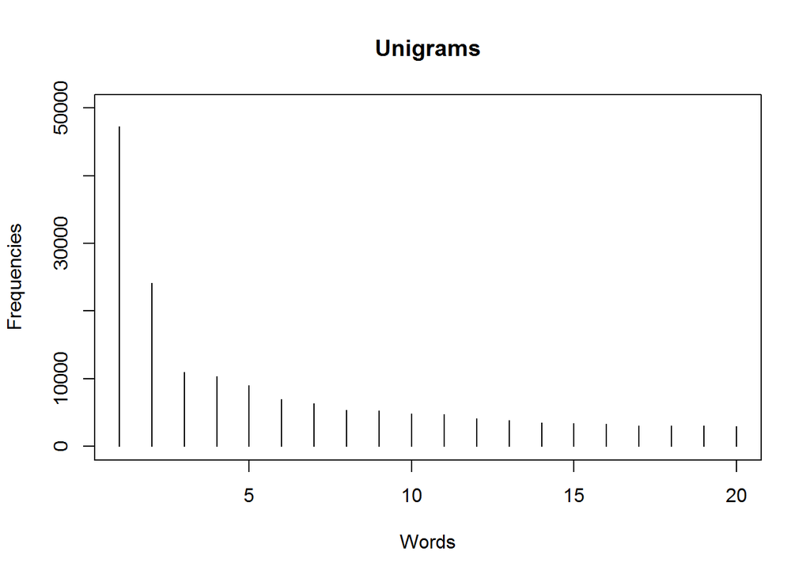

```r
####################### visualize n-gram samples ###############################

## Suppress warnings
options(warn=-1)

# creating data frames containing most frequent words
words_to_print <- words[1:20,]
words2_to_print <- words2[1:20,]
words3_to_print <- words3[1:20,]
words4_to_print <- words4[1:20,]

# plot the data from the data frames above
plot(words_to_print$Frequency, type="h", main="Unigrams",
     xlab="Words", ylab="Frequencies",
     xlim=c(1, 20), ylim=c(0, 50000))
```

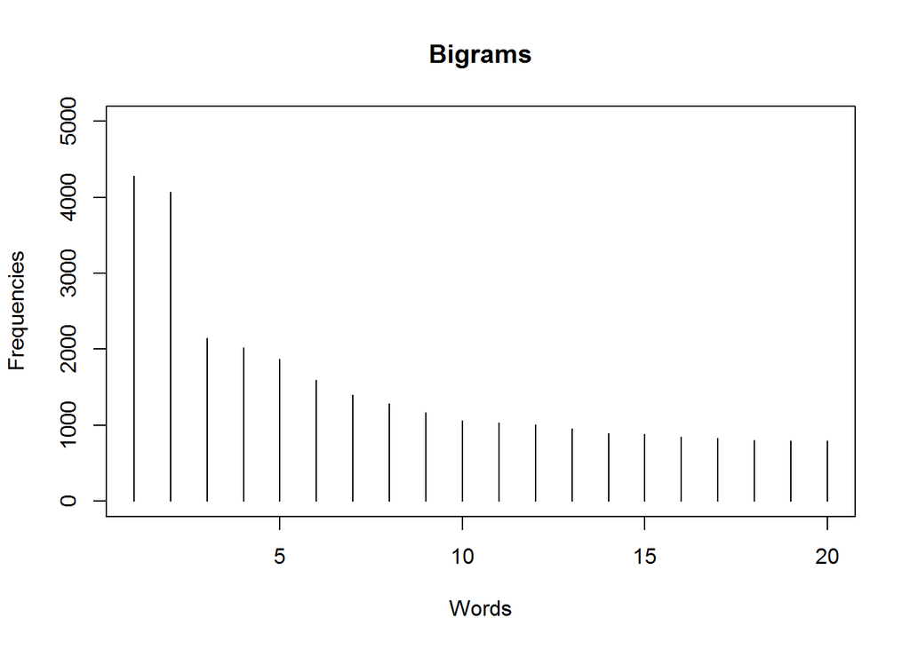

```r
plot(words2_to_print$Frequency, type="h", main="Bigrams",
     xlab="Words", ylab="Frequencies",
     xlim=c(1, 20), ylim=c(0, 5000))
```

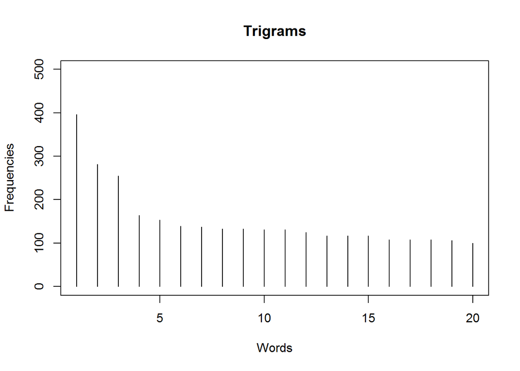

```r
plot(words3_to_print$Frequency, type="h", main="Trigrams",
     xlab="Words", ylab="Frequencies",
     xlim=c(1, 20), ylim=c(0, 500))
```

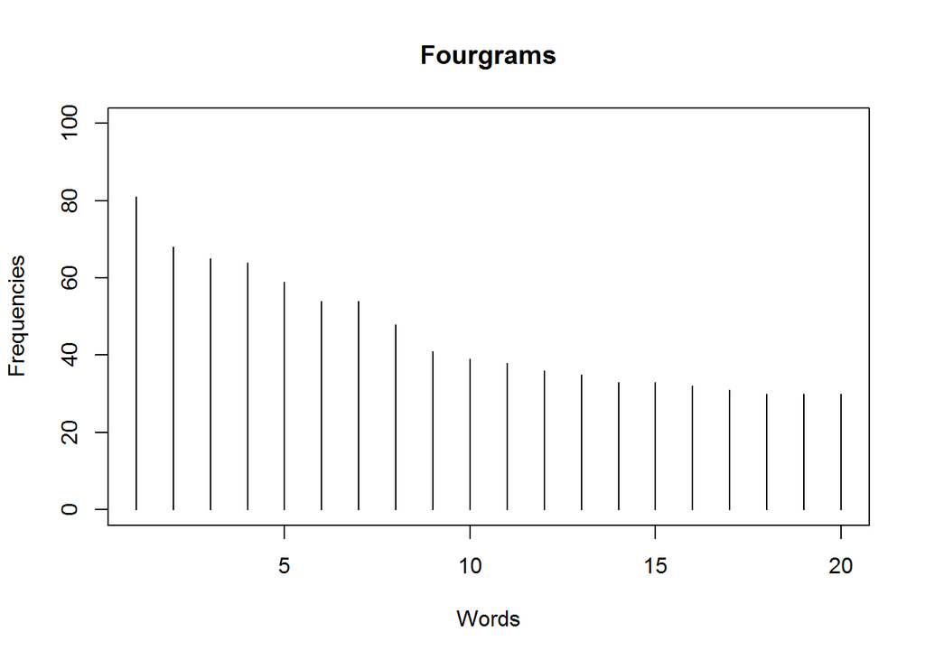

```r
plot(words4_to_print$Frequency, type="h", main="Fourgrams",
     xlab="Words", ylab="Frequencies",
     xlim=c(1, 20), ylim=c(0, 100))
```

# Building Predition Model and the Final App

When building the model, I will employ the following strategy: 1. If one word is suppled, search bigram data frame for the line starting from a supplied word, get the subset of data frame containing bigrams starting with the supplied word, and return the most frequently occuring bigram. 2. If two words are supplied, search trigram data frame for the line starting from the words supplied, get the subset of data frame containing trigrams starting with two supplied words, and return the most frequently occuring trigram. 3. If three words are supplied, search fourgram data frame for the line starting from the words supplied, get teh subset of data frame containing fourgrams starting with the three words supplied, and return the most frequently occuring fourgram.

For the words that are not in the dictionary, I plan to try to use the synonyms() function provided by the **qdap** package. The synonyms() call return a list of lists containing synonyms of the word. I will used obtained synonym to search the dictionary. I will use the last word of the phrase supplied by the to look for the synonyms and to find matching word in the bi-gram data file. If the match is not found, I will inform the user that there is no match.

When building the shiny app, I will generage bigram, trigram, and fourgram data frames from the corresponding data files that I will create during the pre-processing of the supplied data. Once the files are loaded, for every user request, I will run an algorythm that would determine the next word for one, two, three, or more words supplied. I will emphasize utility vs. visual esthetics.

```r
## Suppress warnings
options(warn=-1)

library(qdap, quietly=TRUE)
# Example of using synonyms call

synonyms('cook')
```

```
## $cook.def_1
##  [1] "concoct"     "contrive"    "devise"      "dream up"    "fabricate"
##  [6] "improvise"   "invent"      "manufacture" "plot"        "prepare"
## [11] "scheme"      "trump up"
```

```r
temp <- synonyms('cook')

print(temp[[1]][1])
```

```
## [1] "concoct"
```

```r
# Enable warninigs
options(warn=0)
```

I will need to work on the data preprocessing to speed up the proccess. I am planning to get a list of 100,000 most frequent n-grams from each of the data sets generated to reduce the file size. I will use files containing 100,000 n-grams for the actual application. The subset, despite having fairly limited number of n-grams, will be a fairly good representation of the most common words in the English language. However, as the n-gram size grows, the selection of matching n-grams becomes limited.

However, this is just a plan. I may use alternative approach based more on statistics rather than on text searchers. I feel there may be better appraoches. I think my old computer will not be able to process large enough sample, so I am planning on using about 10% of the data supplied in the data files. If hardware allows, I will use more data.

# References

1. [R and Data Science Reference] [https://github.com/lgreski/datasciencectacontent], last accessed 03/15/2016
2. [Survival Guied to Data Science with R] [http://togaware.com/onepager/], last accessed 03/15/2015
3. [Presentation by M. H. Nierhoff] [https://rpubs.com/nierhoff/cdsc], last accessed 03/15/2015